# TP1 Regresión Lineal Simple

Marcos Buccellato

2023-06-01

# 1.1.Correlación

## Ejercicio1.1.

En el archivo grasacerdos.xlsx se encuentran los datos del peso vivo (PV,en Kg) y al epesor de grasa dorsal(EGD,en mm) de 30 lechones elegidos al azar de una población de porcinos Duroc Jersey del Oeste de la provincia de Buenos Aires. Se pide

```r
grasa <- read_excel('grasacerdos.xlsx')
grasa$PV <- as.numeric(gsub(",", ".", grasa$PV))
grasa$EGD <- as.numeric(gsub(",", ".", grasa$EGD))
```

### (a)Dibujar el diagrama de dispersión e interpretarlo.

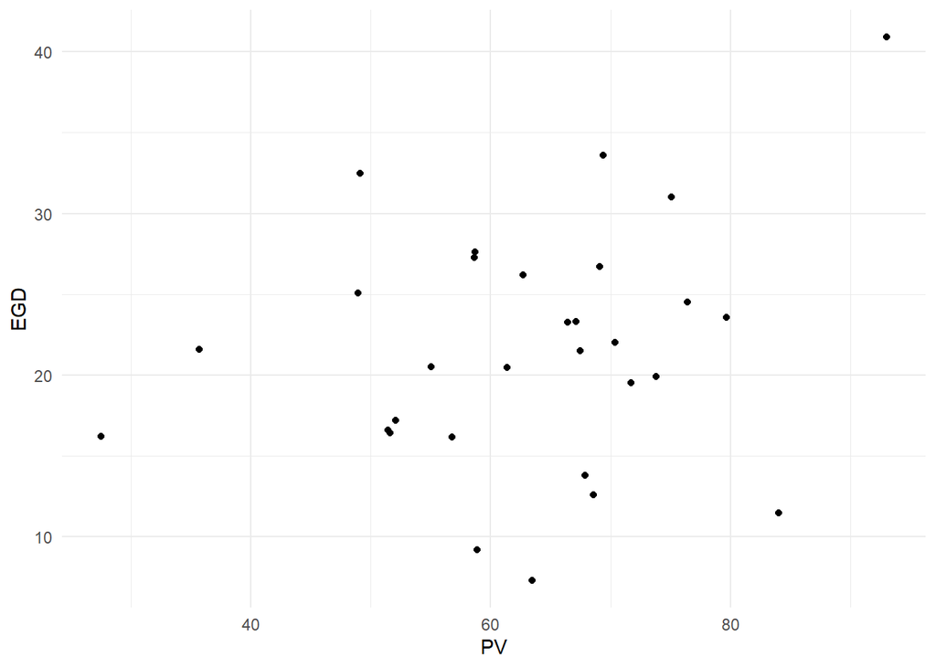

```r
ggplot(grasa, aes(PV, EGD)) +
  geom_point() + theme_minimal()
```

Como cambia el EGD en función del crecimiento del PV.

### (b)Calcular el coeficiente de correlación muestral y explíquelo.

```r
biNormTest <- mvn(data = grasa[2:3], mvnTest = "hz")
corCoeff <- cor(grasa$PV,grasa$EGD, method = "pearson")
print(biNormTest$multivariateNormality)
```

```
##            Test        HZ   p value MVN
## 1 Henze-Zirkler 0.2539437 0.9049686 YES
```

Como el test de binormalidad de las variables dio positivo, puedo usar el coeficiente de perason como indicador de la correlación entre las variables.

### (c)¿Hay suficiente evidencia para admitir asociación entre el peso y el espesor de grasa? (α=0,05). Verifique los supuestos para decidir el indicador que va a utilizar.

```r
corTest <- cor.test(grasa$PV,grasa$EGD, method = "pearson")
```

El resultado de un test de correlación (usando Pearson según se vio en (b)) dio negativo con un p valor de 0.1749942 que es mayor al $\alpha$ = 0,05

## Ejercicio1.2.

Los datos del cuarteto de Anscombe se encuentran en el archivo anscombe.xlsx

```r
anscombre <- read_excel('anscombe.xlsx')
```

Se pide explorar los datos de la siguiente manera:

### (a) Graficar los cuatro pares de datos en un diagrama de dispersión cada uno.

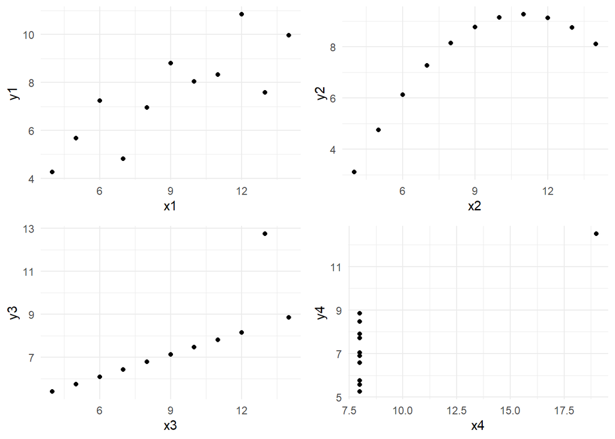

```r
c1 <- ggplot(anscombe, aes(x1, y1)) +
  geom_point() + theme_minimal()
c2 <- ggplot(anscombe, aes(x2, y2))+
  geom_point() + theme_minimal()
c3 <- ggplot(anscombe, aes(x3, y3))+
  geom_point() + theme_minimal()
c4 <- ggplot(anscombe, aes(x4, y4))+
  geom_point() + theme_minimal()
grid.arrange(c1,c2,c3,c4, ncol = 2, nrow = 2)
```

### (b) Hallar los valores medios de las variables para cada par de datos.

```r
colMeans(anscombe)
```

```
##       x1       x2       x3       x4       y1       y2       y3       y4
## 9.000000 9.000000 9.000000 9.000000 7.500909 7.500909 7.500000 7.500909
```

### (c) Hallar los valores de la dispersión para cada conjunto de datos.

```r
sapply(anscombe, sd)
```

```
##       x1       x2       x3       x4       y1       y2       y3       y4
## 3.316625 3.316625 3.316625 3.316625 2.031568 2.031657 2.030424 2.030579
```

### (d) Hallar el coeficiente muestral de correlación lineal en cada caso.

```r
mvn(data = anscombe[c(1,5)], mvnTest = "hz")$multivariateNormality$MVN
```

```
## [1] "YES"
```

```r
mvn(data = anscombe[c(2,6)], mvnTest = "hz")$multivariateNormality$MVN
```

```
## [1] "NO"
```

```r
mvn(data = anscombe[c(3,7)], mvnTest = "hz")$multivariateNormality$MVN
```

```
## [1] "NO"
```

```r
mvn(data = anscombe[c(4,8)], mvnTest = "hz")$multivariateNormality$MVN
```

```
## [1] "NO"
```

```r
cor.test(anscombe$x1,anscombe$y1,method="pearson")$p.value
```

```
## [1] 0.002169629
```

```r
cor.test(anscombe$x2,anscombe$y2,method="spearman")$p.value
```

```
## [1] 0.02305887
```

```r
cor.test(anscombe$x3,anscombe$y3,method="spearman")$p.value
```

```
## [1] 0
```

```r
cor.test(anscombe$x4,anscombe$y4,method="spearman")$p.value
```

```
## [1] 0.1173068
```

### (e) Observar, comentar y concluir.

Los primeros pares de variables son binormales por lo tanto puedo usar pearson. Hay correlación porque ep p-valor es bajo. EN los siguientes no podría usar pearson porque no son binormales, por tal motivo uso spearman. Hay correlación salvo en el caso del cuarto par de variables.

# 1.2.Modelo Lineal Simple

## Ejercicio1.3.

El archivo peso_edad_colest.xlsx disponible en contiene registros correspondiente sa 25 individuos respecto de supeso, su edad y el nivel de colesterol total en sangre.

```r
colest <- read_excel('peso_edad_colest.xlsx')
```

Se pide:

### (a) Realizar el diagrama de dispersión de colesterol en función de la edad y de colesterol en función de peso. Le parece adecuado ajustar un modelo lineal para alguno de estos dos pares de variables?

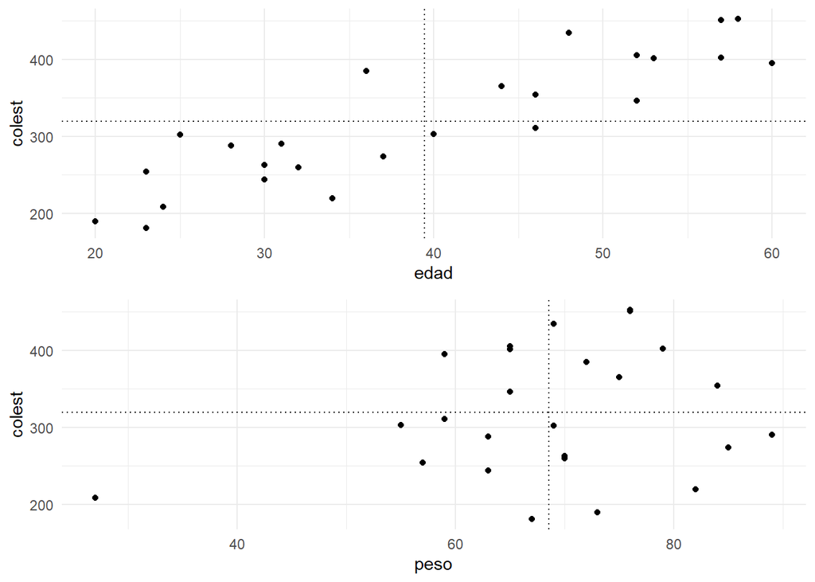

```r
promedios <- colMeans(colest)

c1 <- ggplot(colest, aes(edad, colest)) +
  geom_point() +
  geom_vline(xintercept=promedios[2],linetype="dotted") +
  geom_hline(yintercept=promedios[3],linetype="dotted") +
  theme_minimal()
c2 <- ggplot(colest, aes(peso, colest)) +
  geom_point() +
  geom_vline(xintercept=promedios[1],linetype="dotted") +
  geom_hline(yintercept=promedios[3],linetype="dotted") +
  theme_minimal()
grid.arrange(c1,c2, ncol = 1, nrow = 2)
```

### (b) Estime los coeficientes del modelo lineal para el colesterol en función de la edad.

```r
model <- lm(colest ~ edad, data = colest)
model$coefficients
```

```
## (Intercept)        edad
##   95.502004    5.670842
```

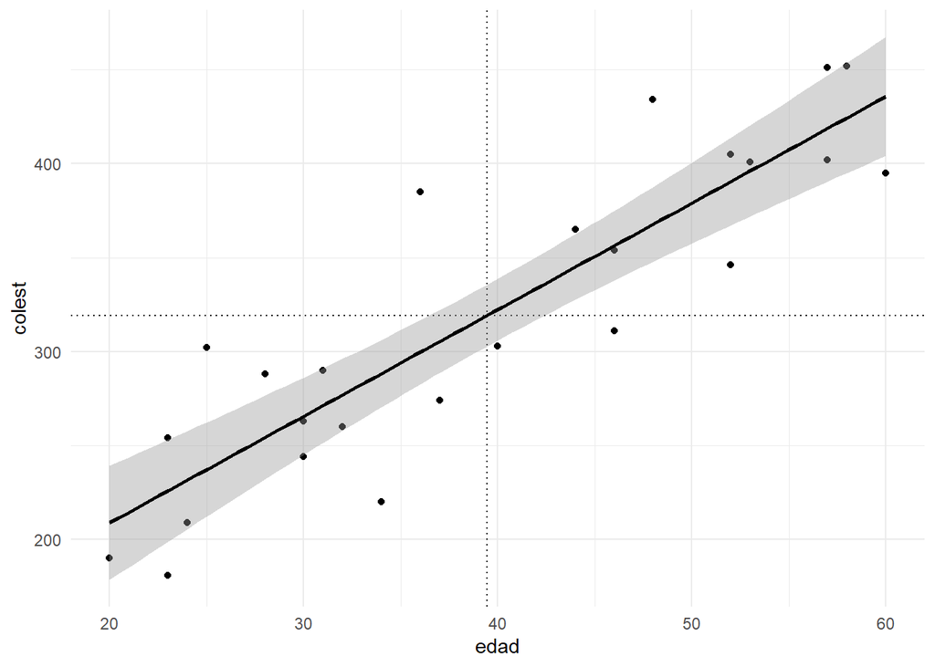

```r
(c1+ geom_smooth(method = "lm", se = TRUE, color = "black") )
```

### (c) Estime intervalos de confianza del 95% para los coeficientes del modelo y compare estos resultados con el test de Wald para los coeficientes.Le parece que hay asociación entre estos test y el test de la regresión?

cálculo de coeficientes de confianza:

```r
ci <- confint(model, level = 0.95)
ci
```

```
##                 2.5 %     97.5 %
## (Intercept) 41.190390 149.813618
## edad         4.358216   6.983467
```

test de Wald:

```r
#install.packages("aod")
library(aod)
coef(model)
```

```
## (Intercept)        edad
##   95.502004    5.670842
```

```r
wald.test(Sigma = vcov(model), b = coef(model), Terms = 1)
```

```
## Wald test:
## ----------
##
## Chi-squared test:
## X2 = 13.2, df = 1, P(> X2) = 0.00028
```

No se muy bien que concluir. Pero entiendo que el test de wald en este caso probaría que existe un coeficiente que es diferente de cero de forma significativa. En este caso el intervalo del coeficiente no incluye al cero, por lo cual sería consistente.

### (d) A partir de esta recta estime los valores de E(Y) para x=25 años y x=48 años. Podría estimarse el valor de E(Y) para x=80 años?

```r
predict(model, newdata = data.frame(edad = c(25,80)))
```

```
##        1        2
## 237.2730 549.1693
```